# TCGA_Analysis

Nasim Bondar Sahebi

2024-02-13

## Load Libraries

```r
library(SummarizedExperiment)
library(dplyr)
library(ggplot2)
library(knitr)
library(DT)
library(limma)
library(EnhancedVolcano)
library(fgsea)
library(msigdbr)
library(gage)
library(pathview)
library(BiocParallel)
```

## Data Loading and Preparation

#### Data Overview

- **Paper name** : Integrated Genomic Characterization of Pancreatic Ductal Adenocarcinoma
- ** PMID **: [28810144](https://www.ncbi.nlm.nih.gov/pmc/articles/PMC5964983/)
- **Patient samples** : 120
- **RNA sequencing (RNA-seq)**: 120 patients, 18416 genes.
- **LOW** : 82 patients
- **HIGHT** : 38 patients

Load the Summarized Experiment data object, extract clinical information, log-transformed FPKM expression data, along with annotations. Prepare the gene expression data for analysis.

```r
# Load your SE result and extract clinical data , expression data and annotation

# Load SE obj
se <- readRDS("~/BHK lab/Pancreas-cancer/output data/SE_TCGA.rds")

# Extract Clinical data
clin <- data.frame(colData(se)) #dim is 120 x 24

# Extract the expression data
expr_fpkm <- assays(se)[["gene_expression"]] #dim is 18416 x 120

# Extract the annotation
annot <- data.frame(rowData(se))  #dim is 18416 x 15

# Display first few rows of the dataset
DT::datatable(round(expr_fpkm[1:8, 1:5], 3))
```

|  | TCGA_2J_AAB1 | TCGA_2J_AAB4 | TCGA_2J_AAB6 | TCGA_2J_AAB8 | TCGA_2J_AAB9 |
| --- | --- | --- | --- | --- | --- |
| A1BG | 6.374 | 5.852 | 6.385 | 5.856 | 6.739 |
| A1CF | 4.721 | 5.767 | 3.2 | 5.123 | 4.488 |
| A2M | 14.266 | 13.951 | 13.056 | 13.815 | 14.569 |
| A2ML1 | 6.441 | 0 | 10.827 | 4.164 | 9.329 |
| A4GALT | 10.591 | 10.175 | 10.132 | 8.622 | 10.138 |
| A4GNT | 8.77 | 5.602 | 1.117 | 3.379 | 5.683 |
| AAAS | 9.42 | 9.063 | 9.707 | 9.649 | 9.755 |
| AACS | 10.221 | 10.262 | 9.186 | 9.417 | 9.331 |

## Data Preparation

Preparing expression data (RNA-seq) for analysis:

1. Restrict expression data to protein-coding genes.
2. Remove low/zero expression genes.

Total 15,884 genes remain for downstream analyses.

```r
# Step 1: Restrict to Protein-Coding Genes.
annot_proteincoding <- annot[annot$gene_type == "protein_coding",] # 17586 protein coding genes.
expr_fpkm <- expr_fpkm[rownames(expr_fpkm) %in% rownames(annot_proteincoding),]
dim(expr_fpkm)
```

```
## [1] 17586   120
```

```r
# Step 2: Filter Low/Zero Expression Genes]

# Data is log2(FPKM+1)
r <- as.numeric(apply(expr_fpkm, 1, function(i) sum(round(i, 6) == round(log2(1), 6))))

# Get the indices of rows to remove
remove <- which(r > dim(expr_fpkm)[2] * 0.5)

# Remove rows from the matrix
expr_fpkm <- expr_fpkm[-remove, ]   #dim is 15884 x 120

DT::datatable(round(expr_fpkm[1:8, 1:5], 3))
```

|  | TCGA_2J_AAB1 | TCGA_2J_AAB4 | TCGA_2J_AAB6 | TCGA_2J_AAB8 | TCGA_2J_AAB9 |
| --- | --- | --- | --- | --- | --- |
| A1BG | 6.374 | 5.852 | 6.385 | 5.856 | 6.739 |
| A1CF | 4.721 | 5.767 | 3.2 | 5.123 | 4.488 |
| A2M | 14.266 | 13.951 | 13.056 | 13.815 | 14.569 |
| A2ML1 | 6.441 | 0 | 10.827 | 4.164 | 9.329 |
| A4GALT | 10.591 | 10.175 | 10.132 | 8.622 | 10.138 |
| A4GNT | 8.77 | 5.602 | 1.117 | 3.379 | 5.683 |
| AAAS | 9.42 | 9.063 | 9.707 | 9.649 | 9.755 |
| AACS | 10.221 | 10.262 | 9.186 | 9.417 | 9.331 |

## Differential gene expression.

- **Use limma approach in R** : To find the differentially expressed genes between LOW and HIGH.
- **P-values are corrected to control false discovery rate (FDR)** using Benjamini-Hochberg approach
- **out put:** TCGCA_Limma_Fit.txt file

```r
# Limma approach applied.
design <- model.matrix(~ clin$low_high)

# Fit the model
fit <- lmFit(expr_fpkm, design)

# Calculate the t-statistics
fit <- eBayes(fit)

# Sort by Pvalue.
top.table <- topTable(fit, sort.by = "P", n = Inf)

# To see How many DE gene are there.
length(which(top.table$adj.P.Val < 0.05))  # no DE genes.
```

```
## [1] 0
```

```r
# Preview
DT::datatable(round(data.frame(top.table),3))
```

|  | logFC | AveExpr | t | P.Value | adj.P.Val | B |
| --- | --- | --- | --- | --- | --- | --- |
| THAP3 | 0.43 | 8.231 | 4.653 | 0 | 0.122 | 3.178 |
| NPRL3 | 0.304 | 9.51 | 4.465 | 0 | 0.122 | 2.53 |
| GPR137 | 0.399 | 9.037 | 4.38 | 0 | 0.122 | 2.244 |
| ARMC5 | 0.461 | 8.252 | 4.263 | 0 | 0.122 | 1.855 |
| ADNP2 | -0.285 | 8.796 | -4.256 | 0 | 0.122 | 1.832 |
| ZNF668 | 0.464 | 8.375 | 4.17 | 0 | 0.122 | 1.55 |
| ABCB8 | 0.352 | 9.489 | 4.138 | 0 | 0.122 | 1.448 |
| UBE2J2 | 0.389 | 9.616 | 4.126 | 0 | 0.122 | 1.41 |
| PQLC2 | 0.37 | 8.304 | 4.098 | 0 | 0.122 | 1.319 |
| FOXN2 | -0.415 | 8.768 | -4.094 | 0 | 0.122 | 1.307 |

[output cut: 15874 more lines]

```r
# Save top table to .txt file.
top.table$Gene <- rownames(top.table)
write.table(top.table, file = "~/BHK lab/Pancreas-cancer/output data/TCGCA_Limma_Fit.txt", row.names = F, sep = "\t", quote = F)
```

## Volcano plot

- **Volcano Plot:** based on P value and FDR

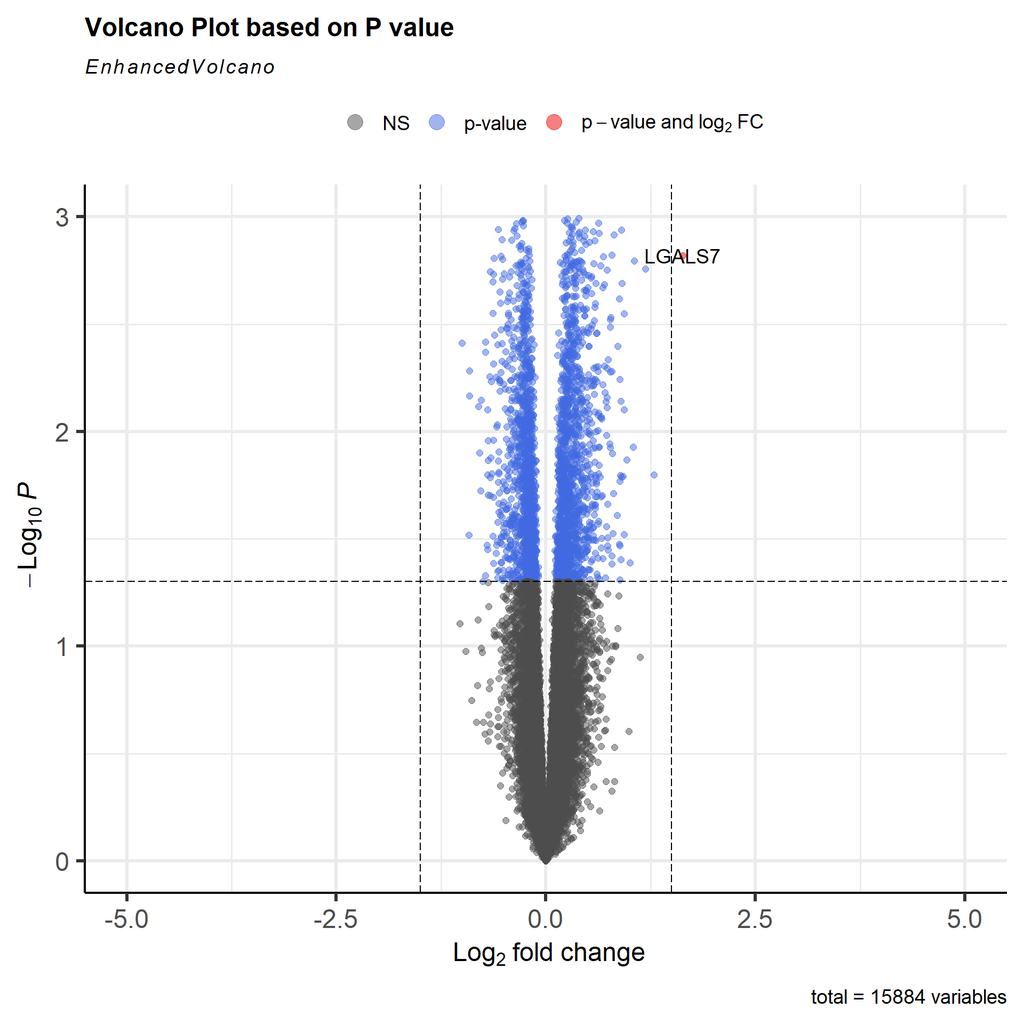

```r
# 1. Volcano plot.

# 1.1 Volcano Plot based on P value
EnhancedVolcano(top.table,
    lab = rownames(top.table),
    x = 'logFC',
    y = 'P.Value',
    pCutoff = 0.05,
    FCcutoff = 1.5,
    xlim = c(-5, 5),
    ylim = c(0, -log10(10e-4)),
    title= 'Volcano Plot based on P value'
    )
```

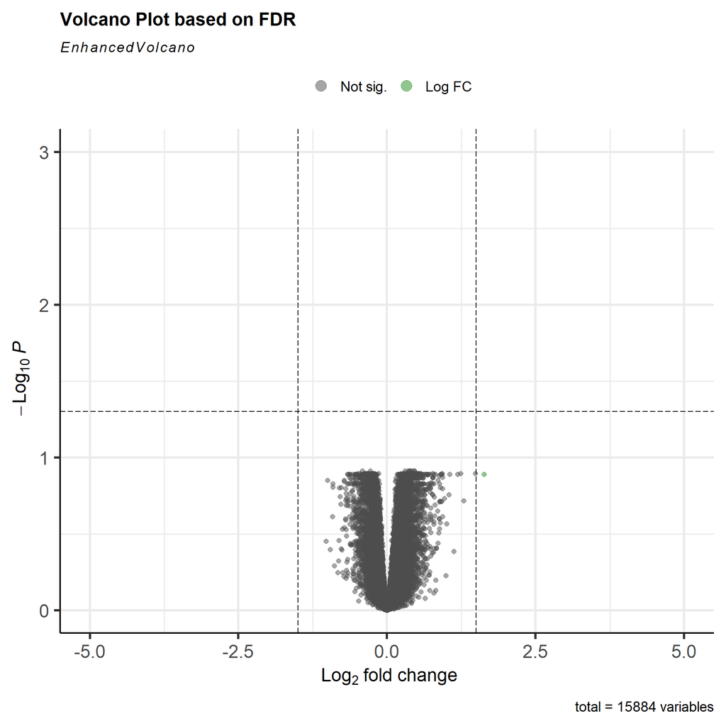

```r
# 1.2 Volcano Plot based on FDR
# adjusted p-values as red
EnhancedVolcano(top.table,
    lab = rownames(top.table),
    x = 'logFC',
    y = 'adj.P.Val',
    pCutoff = 0.05,
    FCcutoff = 1.5,
    xlim = c(-5, 5),
    ylim = c(0, -log10(10e-4)),
    legendLabels=c('Not sig.','Log FC','adj p-value',
      'adj p-value & Log FC'),
    title= 'Volcano Plot based on FDR',)
```

## MSigDB Pathway analysis

- To Identify the associated pathways or genes sets.
- Downloaded hallmark(H) , KEGG gene sets from [MSigDB website](https://www.gsea-msigdb.org/gsea/msigdb/human/collections.jsp#H).
- Conduct GSEA with the fgsea package using “top.table” from step 2.

## Hallmark Geneset.

```r
# Load gene sets from a GMT file for pathway analysis
pathwaysH <- gmtPathways("~/BHK lab/Pancreas-cancer/GSEA/h.all.v2023.2.Hs.symbols.gmt")

# 1. Create ranks

# Create 'ranks' vector from 'top.table' with logFC as values and gene names as names.
ranks <- top.table$logFC
names(ranks) <- top.table$Gene
ranks <- sort(ranks, decreasing = T)

# Preview the data table of ranks.
DT::datatable(data.frame(ranks))
```

|  | ranks |
| --- | --- |
| LGALS7 | 1.632694979771501 |
| C4orf48 | 1.486348467137353 |
| LGALS7B | 1.289120469619383 |
| JSRP1 | 1.241056551634786 |
| NOXO1 | 1.190694225028239 |
| ADIPOQ | 1.124258163230424 |
| NPW | 1.057002514627085 |
| CYP2W1 | 1.039514356262514 |
| FABP6 | 1.006112429652118 |
| PPY | 0.9923896589171974 |

[output cut: 15862 more lines]

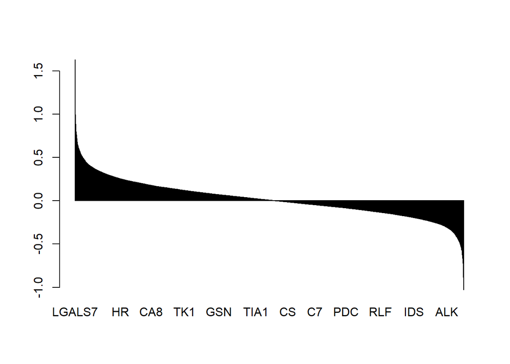

```r
# 2. Bar Plot
# Display the ranked fold changes.
barplot(ranks)
```

```r
# Set BiocParallel to use a single core to see if the problem persists
#register(SerialParam())

# 3. Conduct analysis
# Run fgsea with 'pathwaysH' and 'ranks'.
fgseaRes <- fgsea(pathwaysH, ranks)
fgseaRes <- na.omit(fgseaRes)

fgseaResTidy <- fgseaRes %>%
  as_tibble() %>%
  arrange(desc(NES)) #order by NES

# Combine genes in leadingEdge with semicolons
fgseaResTidy$leadingEdge <- sapply(fgseaResTidy$leadingEdge, paste, collapse = ";")
fgseaResTidy <- fgseaResTidy[order(fgseaResTidy$padj), ]

# Show in a Tidy table.
head(fgseaResTidy)
```

```
## # A tibble: 6 × 8
##   pathway                    pval    padj log2err     ES   NES  size leadingEdge
##   <chr>                     <dbl>   <dbl>   <dbl>  <dbl> <dbl> <int> <chr>
## 1 HALLMARK_UV_RESPONSE_DN 7.90e-8 3.95e-6   0.705 -0.431 -2.10   137 GCNT1;RASA…
## 2 HALLMARK_PROTEIN_SECRE… 2.90e-5 7.25e-4   0.576 -0.426 -1.93    94 ADAM10;ATP…
## 3 HALLMARK_MITOTIC_SPIND… 5.24e-5 8.74e-4   0.557 -0.340 -1.75   196 RAPGEF6;PP…
## 4 HALLMARK_G2M_CHECKPOINT 1.67e-4 2.08e-3   0.519 -0.318 -1.60   182 CCNT1;BARD…
## 5 HALLMARK_ANDROGEN_RESP… 2.20e-4 2.20e-3   0.519 -0.390 -1.77    95 FKBP5;LIFR…
## 6 HALLMARK_KRAS_SIGNALIN… 1.58e-3 1.17e-2   0.455  0.369  1.59   169 LGALS7;SER…
```

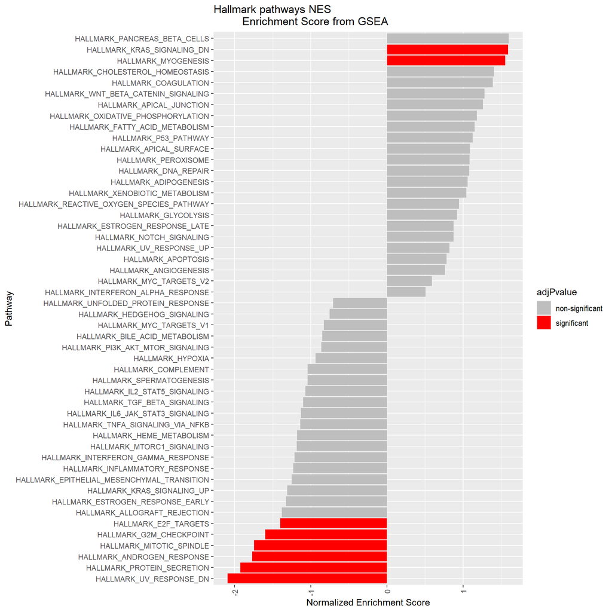

```r
# Save fgseaRes as txt file.
write.table(fgseaResTidy, "~/BHK lab/Pancreas-cancer/output data/TCGA_fgseaRes_HRank.txt", sep = "\t", row.names = FALSE, quote = FALSE)

# Mark "significant" if adjusted p-value <= 0.05, else "non-significant".
fgseaResTidy$adjPvalue <- ifelse(fgseaResTidy$padj <= 0.05, "significant", "non-significant")

# Define colors for significance: grey for non-significant and red for significant results.
cols <- c("non-significant" = "grey", "significant" = "red")

# Using ggplot: reorder pathways by NES, fill bars based on significance, flip coordinates for readability.
ggplot(fgseaResTidy, aes(reorder(pathway, NES), NES, fill = adjPvalue)) + geom_col() +
    scale_fill_manual(values = cols) + coord_flip() +
    theme(axis.text.x = element_text(angle = 90, vjust = 0.5, hjust=1)) +
    labs(x = "Pathway", y = "Normalized Enrichment Score", title = "Hallmark pathways NES
         Enrichment Score from GSEA")
```

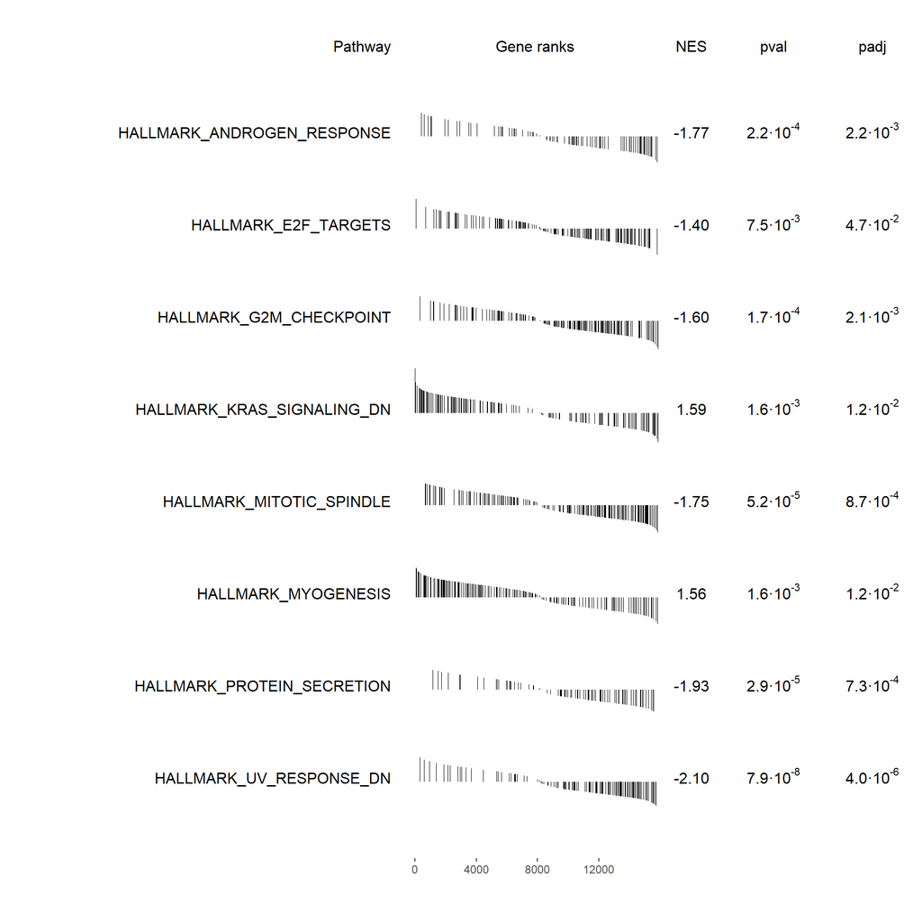

```r
# 4. GSEA Results Table Plot.
# Plot GSEA table for significant pathways (padj < 0.05) using a GSEA parameter of 0.5.
plotGseaTable(pathwaysH[fgseaRes$pathway[fgseaRes$padj < 0.05]], ranks, fgseaRes, gseaParam=0.5)
```

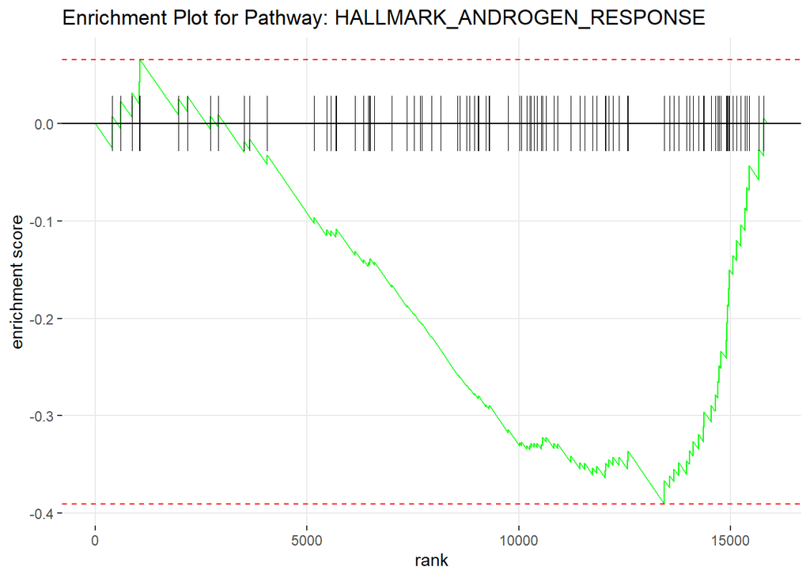

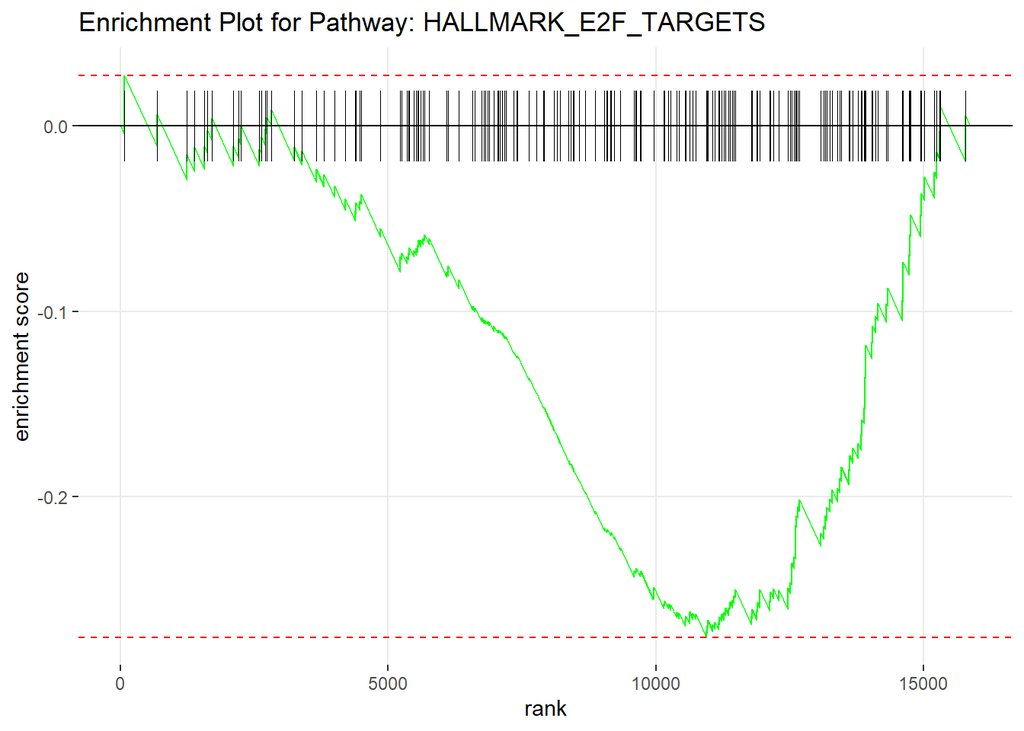

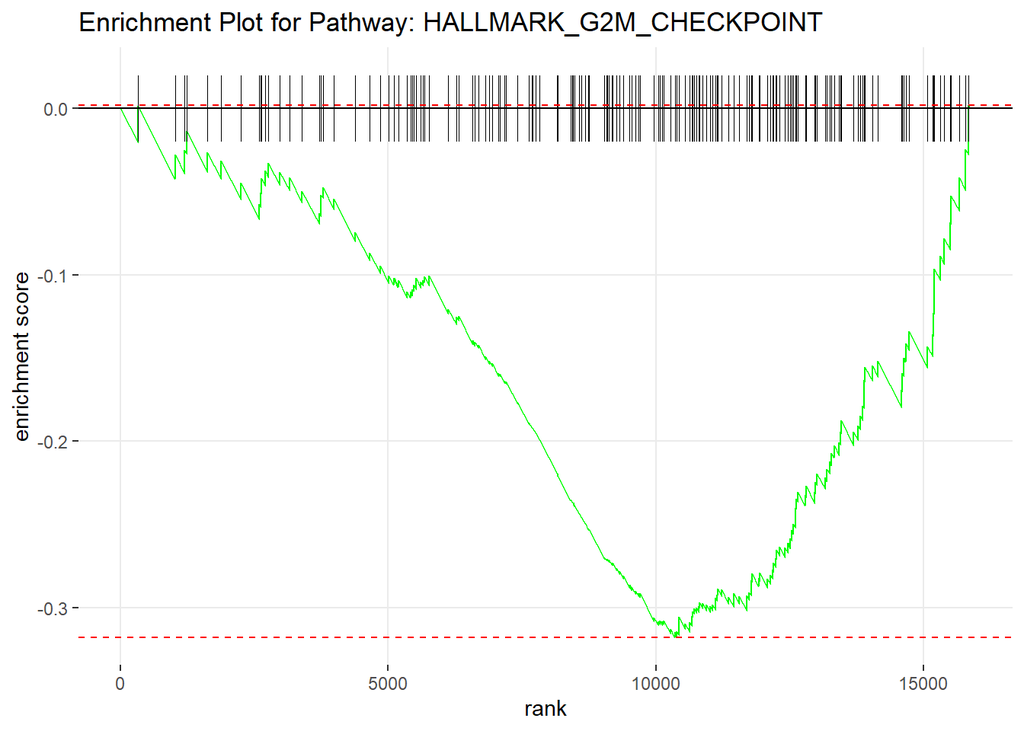

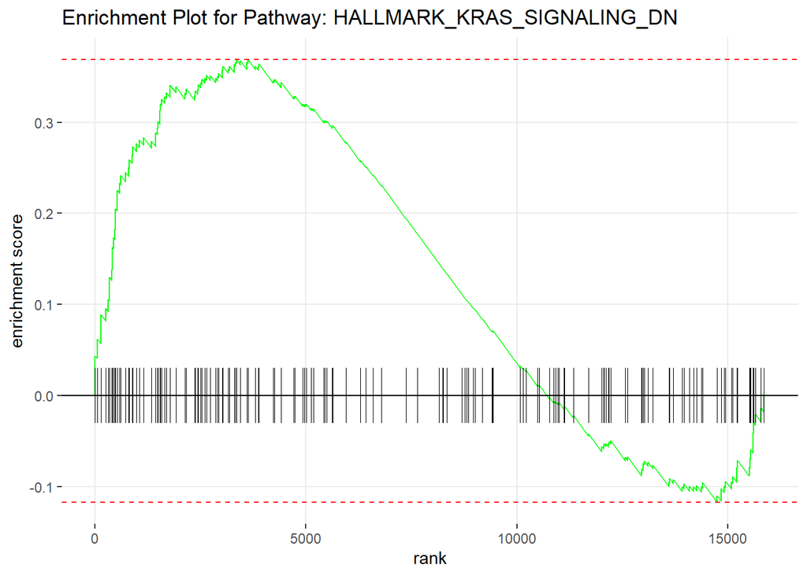

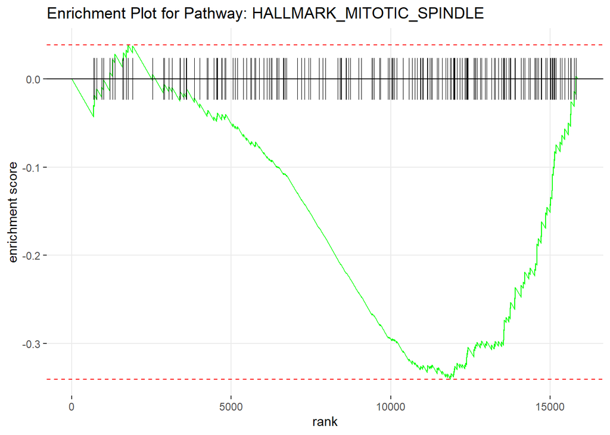

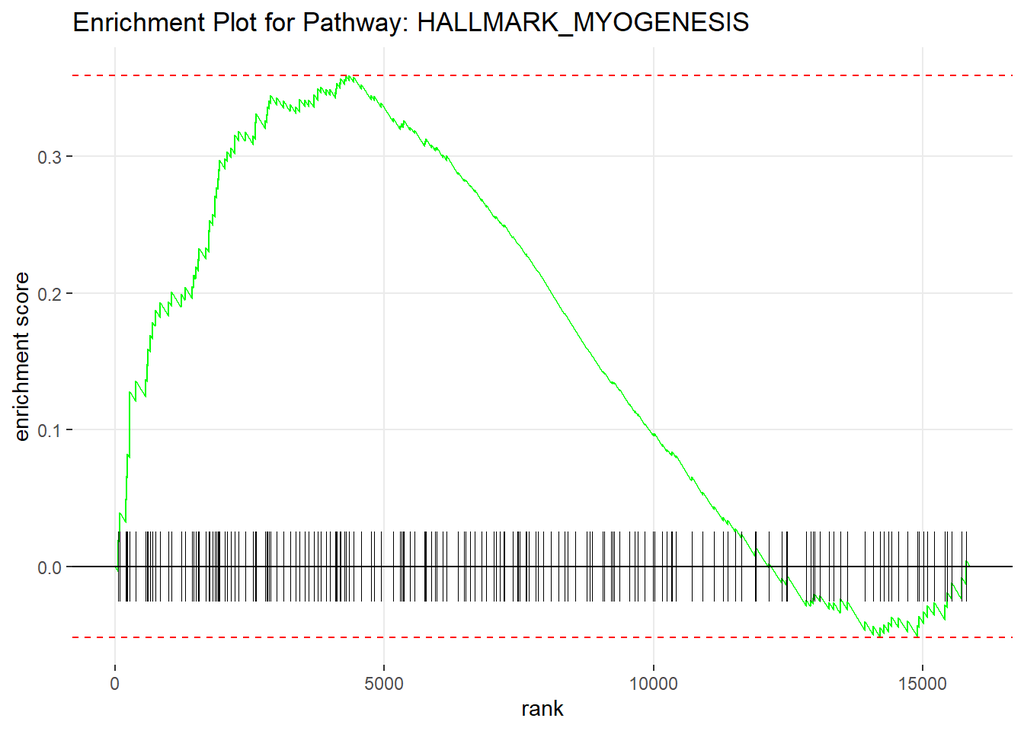

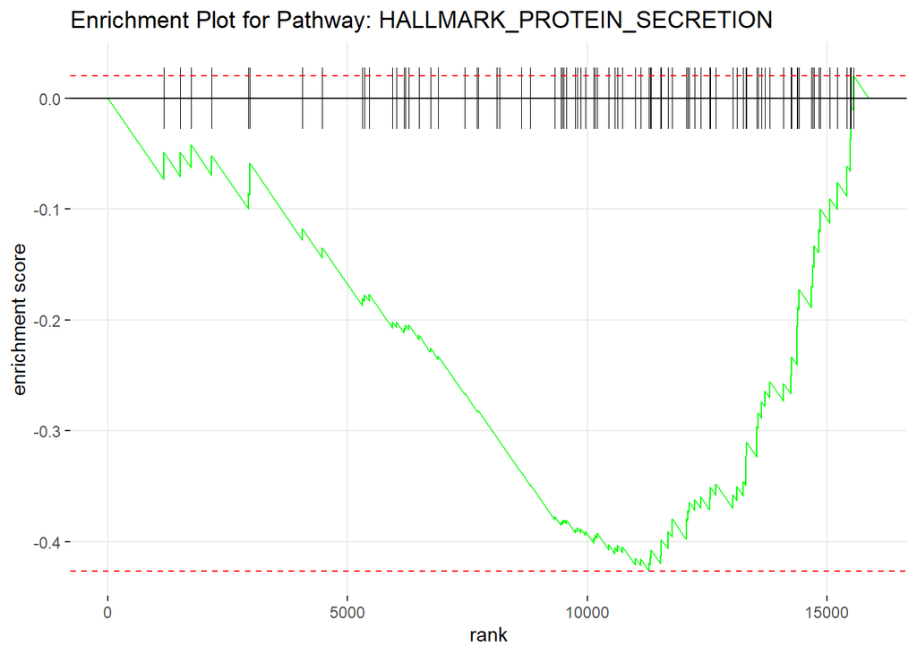

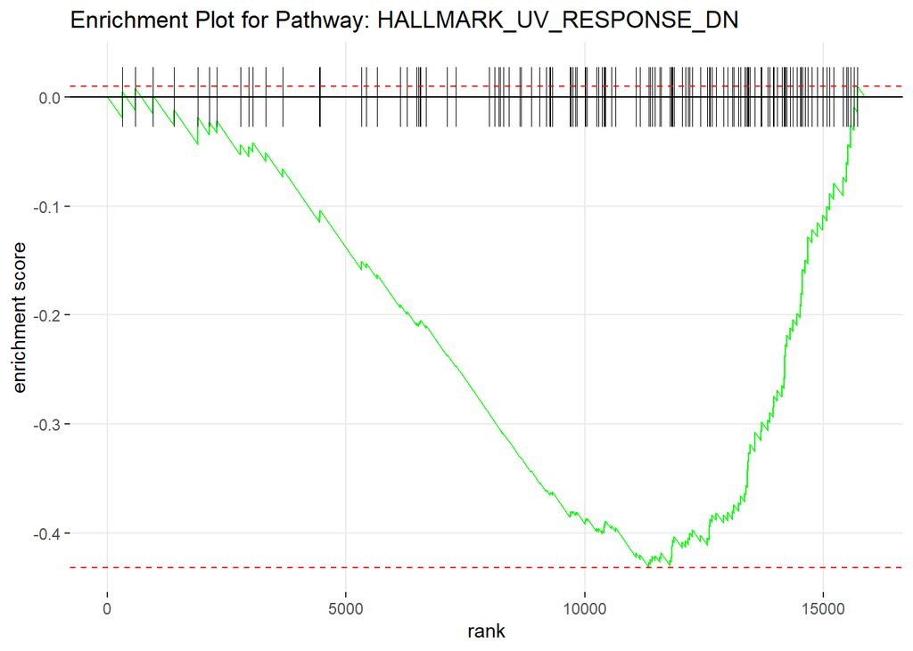

```r
# 5.  Enrichment score plot.

# For significant pathways # 8 pathways.

# Store the list of significant pathways (padj < 0.05).
significant_pathways <- fgseaRes$pathway[fgseaRes$padj < 0.05]

# Use a for loop to iterate and plot enrichment for each significant pathway
for (i in significant_pathways) {
  enrichment_plot <- plotEnrichment(pathwaysH[[i]], ranks)
  enrichment_plot <- enrichment_plot + ggtitle(paste("Enrichment Plot for Pathway:",i))
  print(enrichment_plot)
}
```

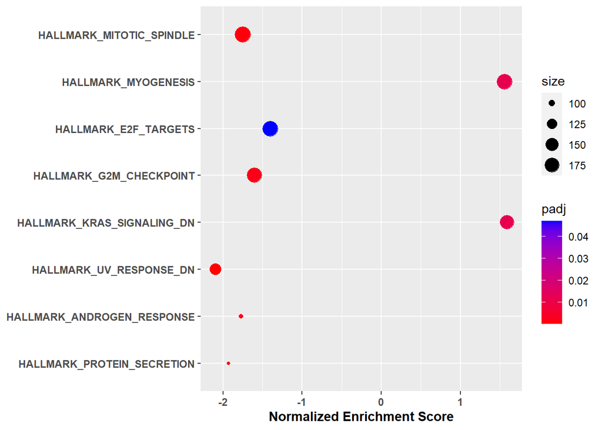

```r
# Plot significant pathways as points with a gradient color based on p-value and size based on a 'size' variable.
ggplot(fgseaResTidy[fgseaResTidy$padj < 0.05, ], aes(y=reorder(pathway, size),x= NES)) + geom_point(aes(color=padj,size=size)) +
  scale_color_gradientn(colours = c("red","blue")) +
  labs(x='Normalized Enrichment Score', y=NULL ) +
  theme( axis.title = element_text(face='bold'), axis.text = element_text (face='bold') )
```

## KEGG_MEDICUS

```r
# Load KEGG_MEDICUS pathways.
pathwaysKEG<- gmtPathways("~/BHK lab/Pancreas-cancer/GSEA/c2.cp.kegg_medicus.v2023.2.Hs.symbols.gmt")

# Perform fgsea with KEGG pathways
fgseaRes_kegg <- fgsea(pathwaysKEG, ranks)

# Organize and sort KEGG results by NES
fgseaResTidy_kegg <- fgseaRes_kegg %>%
  as_tibble() %>%
  arrange(desc(NES))

# Combine genes in leadingEdge with semicolons
fgseaResTidy_kegg$leadingEdge <- sapply(fgseaResTidy_kegg$leadingEdge, paste, collapse = ";")

# Show in a Tidy table of keg.
head(fgseaResTidy_kegg)
```

```
## # A tibble: 6 × 8
##   pathway                       pval  padj log2err    ES   NES  size leadingEdge
##   <chr>                        <dbl> <dbl>   <dbl> <dbl> <dbl> <int> <chr>
## 1 KEGG_MEDICUS_REFERENCE_TI… 0.00155 0.195   0.455 0.564  1.80    32 CLDN6;CLDN…
## 2 KEGG_MEDICUS_REFERENCE_WN… 0.00364 0.205   0.432 0.587  1.75    24 NOTUM;WNT6…
## 3 KEGG_MEDICUS_VARIANT_MUTA… 0.00264 0.195   0.432 0.521  1.72    39 NDUFS7;NDU…
## 4 KEGG_MEDICUS_VARIANT_MUTA… 0.00309 0.195   0.432 0.517  1.71    39 NDUFS7;NDU…
## 5 KEGG_MEDICUS_REFERENCE_EL… 0.00485 0.250   0.407 0.519  1.71    38 NDUFS7;NDU…
## 6 KEGG_MEDICUS_ENV_FACTOR_A… 0.00803 0.301   0.381 0.634  1.70    16 COX4I2;COX…
```

```r
# Save fgseaRes_keg as txt file.
write.table(fgseaResTidy_kegg, "~/BHK lab/Pancreas-cancer/output data/TCGA_fgseaRes_kegMEDRank.txt", sep = "\t", row.names = FALSE, quote = FALSE)
```

no significant pathway is found based on ‘padj’

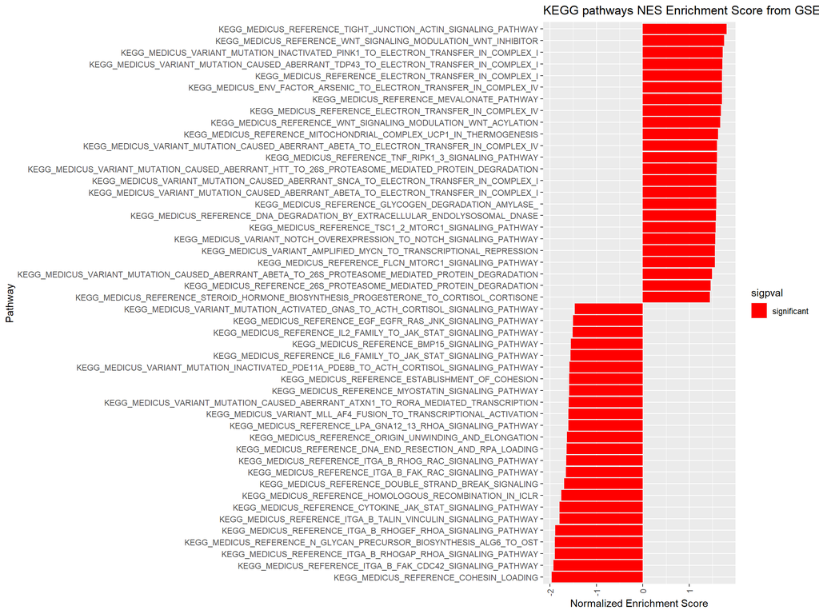

```r
#1.1 no significant pathway is detected based on 'padj'

# # Mark "significant" if adjusted p-value <= 0.05, else "non-significant".
# fgseaResTidy_kegg$adjPvalue <- ifelse(fgseaResTidy_kegg$padj <= 0.05, "significant", "non-significant")
#
# #Create a ggplot of significant pathways, with bars colored based on adjusted p-value significance.
# ggplot(fgseaResTidy_kegg[fgseaResTidy_kegg$padj < 0.05, ], aes(reorder(pathway, NES), NES, fill = adjPvalue)) +
#   geom_col() +
#   scale_fill_manual(values = cols) +
#   coord_flip() +
#   theme(axis.text.x = element_text(angle = 90, vjust = 0.5, hjust=1)) +
#   labs(x = "Pathway", y = "Normalized Enrichment Score", title = "KEGG pathways NES Enrichment Score from GSEA")


#1.2 check pathway based on 'pval'
fgseaResTidy_kegg$sigpval <- ifelse(fgseaResTidy_kegg$pval <= 0.05, "significant", "non-significant")

ggplot(fgseaResTidy_kegg[fgseaResTidy_kegg$pval < 0.05, ], aes(reorder(pathway, NES), NES, fill = sigpval)) +
  geom_col() +
  scale_fill_manual(values = cols) +
  coord_flip() +
  theme(axis.text.x = element_text(angle = 90, vjust = 0.5, hjust=1)) +
  labs(x = "Pathway", y = "Normalized Enrichment Score", title = "KEGG pathways NES Enrichment Score from GSEA")
```

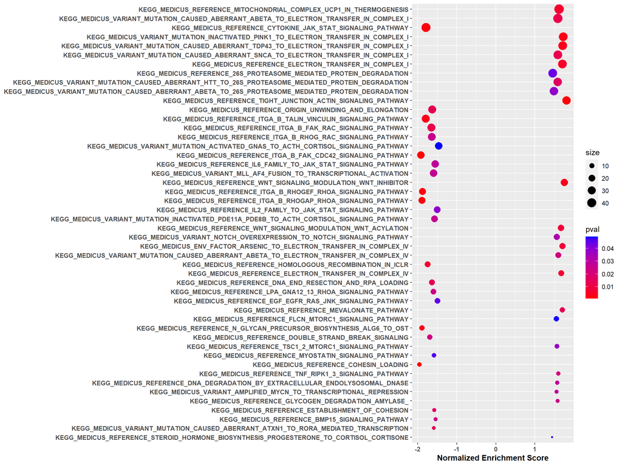

```r
# Plot significant pathways as points with a gradient color based on p-value and size based on a 'size' variable.
ggplot(fgseaResTidy_kegg[fgseaResTidy_kegg$pval < 0.05, ], aes(y=reorder(pathway, size),x= NES)) + geom_point(aes(color=pval,size=size)) +
  scale_color_gradientn(colours = c("red","blue")) +
  labs(x='Normalized Enrichment Score', y=NULL ) +
  theme( axis.title = element_text(face='bold'), axis.text = element_text (face='bold') )
```

```r
# Load KEGG_MEDICUS pathways.
pathwaysKEG_LEG <- gmtPathways("~/BHK lab/Pancreas-cancer/GSEA/c2.cp.kegg_legacy.v2023.2.Hs.symbols.gmt")

# Perform fgsea with KEGG pathways
fgseaRes_kegg <- fgsea(pathwaysKEG, ranks)

# Organize and sort KEGG results by NES
fgseaResTidy_kegg <- fgseaRes_kegg %>%
  as_tibble() %>%
  arrange(desc(NES))

# Combine genes in leadingEdge with semicolons
fgseaResTidy_kegg$leadingEdge <- sapply(fgseaResTidy_kegg$leadingEdge, paste, collapse = ";")

# Show in a Tidy table of keg.
head(fgseaResTidy_kegg)
```

```
## # A tibble: 6 × 8
##   pathway                       pval  padj log2err    ES   NES  size leadingEdge
##   <chr>                        <dbl> <dbl>   <dbl> <dbl> <dbl> <int> <chr>
## 1 KEGG_MEDICUS_REFERENCE_TI… 0.00131 0.168   0.455 0.564  1.83    32 CLDN6;CLDN…
## 2 KEGG_MEDICUS_REFERENCE_WN… 0.00385 0.199   0.432 0.587  1.77    24 NOTUM;WNT6…
## 3 KEGG_MEDICUS_VARIANT_MUTA… 0.00224 0.179   0.432 0.521  1.75    39 NDUFS7;NDU…
## 4 KEGG_MEDICUS_VARIANT_MUTA… 0.00252 0.179   0.432 0.517  1.74    39 NDUFS7;NDU…
## 5 KEGG_MEDICUS_REFERENCE_EL… 0.00318 0.179   0.432 0.519  1.73    38 NDUFS7;NDU…
## 6 KEGG_MEDICUS_ENV_FACTOR_A… 0.00603 0.287   0.407 0.634  1.71    16 COX4I2;COX…
```

```r
# Save fgseaRes_keg as txt file.
write.table(fgseaResTidy_kegg, "~/BHK lab/Pancreas-cancer/output data/TCGA_fgseaRes_keggLEGRank.txt", sep = "\t", row.names = FALSE, quote = FALSE)
```

no significant pathway based on ‘padj’

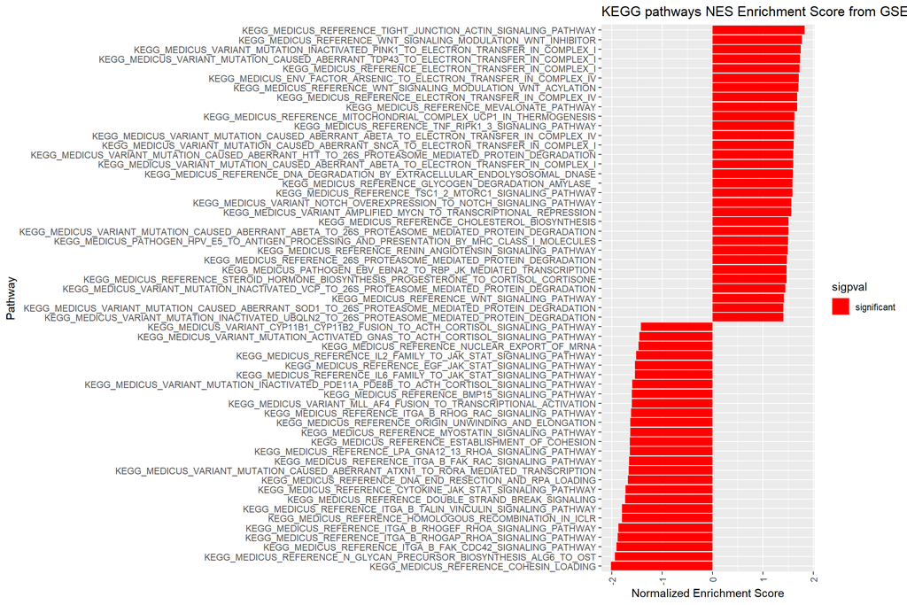

```r
# Mark "significant" if adjusted p-value <= 0.05, else "non-significant".
fgseaResTidy_kegg$adjPvalue <- ifelse(fgseaResTidy_kegg$padj <= 0.05, "significant", "non-significant")

#1.1 no significant pathway based on 'padj'

# Create a ggplot of significant pathways, with bars colored based on adjusted p-value significance.
# ggplot(fgseaResTidy_kegg[fgseaResTidy_kegg$padj < 0.05, ], aes(reorder(pathway, NES), NES, fill = adjPvalue)) +
#   geom_col() +
#   scale_fill_manual(values = cols) +
#   coord_flip() +
#   theme(axis.text.x = element_text(angle = 90, vjust = 0.5, hjust=1)) +
#   labs(x = "Pathway", y = "Normalized Enrichment Score", title = "KEGG (legacy) pathways NES Enrichment Score from GSEA")
#
#
# # Plot significant pathways as points with a gradient color based on p-value and size based on a 'size' variable.
# ggplot(fgseaResTidy_kegg[fgseaResTidy_kegg$padj < 0.05, ], aes(y=reorder(pathway, size),x= NES)) + geom_point(aes(color=padj,size=size)) +
#   scale_color_gradientn(colours = c("red","blue")) +
#   labs(x='Normalized Enrichment Score', y=NULL ) +
#   theme( axis.title = element_text(face='bold'), axis.text = element_text (face='bold') )

#1.2 check  significant pathway based on 'pval'

fgseaResTidy_kegg$sigpval <- ifelse(fgseaResTidy_kegg$pval <= 0.05, "significant", "non-significant")

ggplot(fgseaResTidy_kegg[fgseaResTidy_kegg$pval < 0.05, ], aes(reorder(pathway, NES), NES, fill = sigpval)) +
  geom_col() +
  scale_fill_manual(values = cols) +
  coord_flip() +
  theme(axis.text.x = element_text(angle = 90, vjust = 0.5, hjust=1)) +
  labs(x = "Pathway", y = "Normalized Enrichment Score", title = "KEGG pathways NES Enrichment Score from GSEA")
```

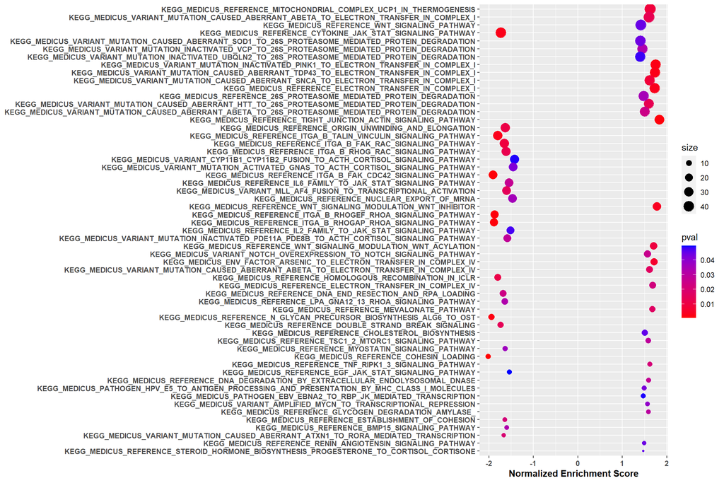

```r
# Plot significant pathways as points with a gradient color based on p-value and size based on a 'size' variable.
ggplot(fgseaResTidy_kegg[fgseaResTidy_kegg$pval < 0.05, ], aes(y=reorder(pathway, size),x= NES)) + geom_point(aes(color=pval,size=size)) +
  scale_color_gradientn(colours = c("red","blue")) +
  labs(x='Normalized Enrichment Score', y=NULL ) +
  theme( axis.title = element_text(face='bold'), axis.text = element_text (face='bold') )
```